#() Cookbook

- ID for each pokemon
- Name: Name of each pokemon
- Type 1: Each pokemon has a type, this determines weakness/resistance to attacks
- Type 2: Some pokemon are dual type and have 2
- Total: sum of all stats that come after this, a general guide to how strong a pokemon is
- HP: hit points, or health, defines how much damage a pokemon can withstand before fainting
- Attack: the base modifier for normal attacks (eg. Scratch, Punch)
- Defense: the base damage resistance against normal attacks
- SP Atk: special attack, the base modifier for special attacks (e.g. fire blast, bubble beam)
- SP Def: the base damage resistance against special attacks
- Speed: determines which pokemon attacks first each round

# Q1

```r
library(tidyverse)
library(tidymodels)
library(vroom)
library(glmnet)
tidymodels_prefer()
```

```r
library(janitor)
pokemon <- vroom("data/Pokemon.csv")
pokemon <- clean_names(pokemon)
view(pokemon)
```

`clean_names` convert all the names to conventional C-style naming scheme (ascii, default lowercase, underscore). So all the names are easier to use when calling them in R, and less prone to incompatability and human errors

# Q2

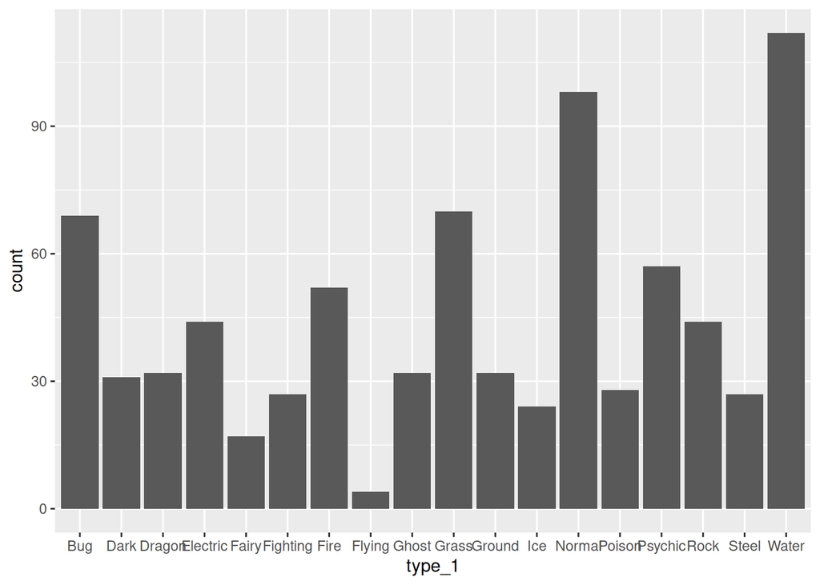

```r
pokemon %>%
    ggplot(aes(x = type_1)) +
    geom_bar()
```

```r
length(unique(pokemon$type_1))
```

```
## [1] 18
```

There’re 18 types

```r
pokemon_cleaned <- pokemon %>%
    filter(type_1 %in% c("Bug", "Fire", "Grass", "Normal", "Water", "Psychic"))

pokemon_cleaned$type_1 <- factor(pokemon_cleaned$type_1)
pokemon_cleaned$legendary <- factor(pokemon_cleaned$legendary,
    c("TRUE", "FALSE"))

levels(pokemon_cleaned$type_1)
```

```
## [1] "Bug"     "Fire"    "Grass"   "Normal"  "Psychic" "Water"
```

```r
levels(pokemon_cleaned$legendary)
```

```
## [1] "TRUE"  "FALSE"
```

# Q3

```r
pokemon_split <- initial_split(pokemon_cleaned, strata = type_1)
pokemon_training <- training(pokemon_split)
pokemon_testing <- testing(pokemon_split)
```

```r
pokemon_folded <- pokemon_training %>%
    vfold_cv(, v = 5, strata = type_1)
```

Make sure every fold has the same amount of type distribution for fitting

# Q4

```r
elastic_recipe <- pokemon_training %>%
    recipe(type_1 ~ legendary +
        generation +
        sp_atk +
        attack +
        speed +
        defense +
        hp +
        sp_def) %>%
    step_dummy(all_nominal_predictors()) %>%
    step_normalize(all_predictors())
```

# Q5

```r
elastic_spec <- multinom_reg(penalty = tune(), mixture = tune()) %>%
    set_engine("glmnet") %>%
    set_mode("classification")

penalty_grid <- grid_regular(penalty(c(-5, 5)), mixture(c(0,1)), levels = 10)
```

# Q6

```r
elastic_workflow <- workflow() %>%
    add_recipe(elastic_recipe) %>%
    add_model(elastic_spec)

elastic_res <- tune_grid(
    elastic_workflow,
    resamples = pokemon_folded,
    grid = penalty_grid)
elastic_res
```

```
## # Tuning results
## # 5-fold cross-validation using stratification
## # A tibble: 5 × 4
##   splits           id    .metrics           .notes
##   <list>           <chr> <list>             <list>
## 1 <split [270/71]> Fold1 <tibble [200 × 6]> <tibble [0 × 3]>
## 2 <split [271/70]> Fold2 <tibble [200 × 6]> <tibble [0 × 3]>
## 3 <split [273/68]> Fold3 <tibble [200 × 6]> <tibble [0 × 3]>
## 4 <split [274/67]> Fold4 <tibble [200 × 6]> <tibble [0 × 3]>
## 5 <split [276/65]> Fold5 <tibble [200 × 6]> <tibble [0 × 3]>
```

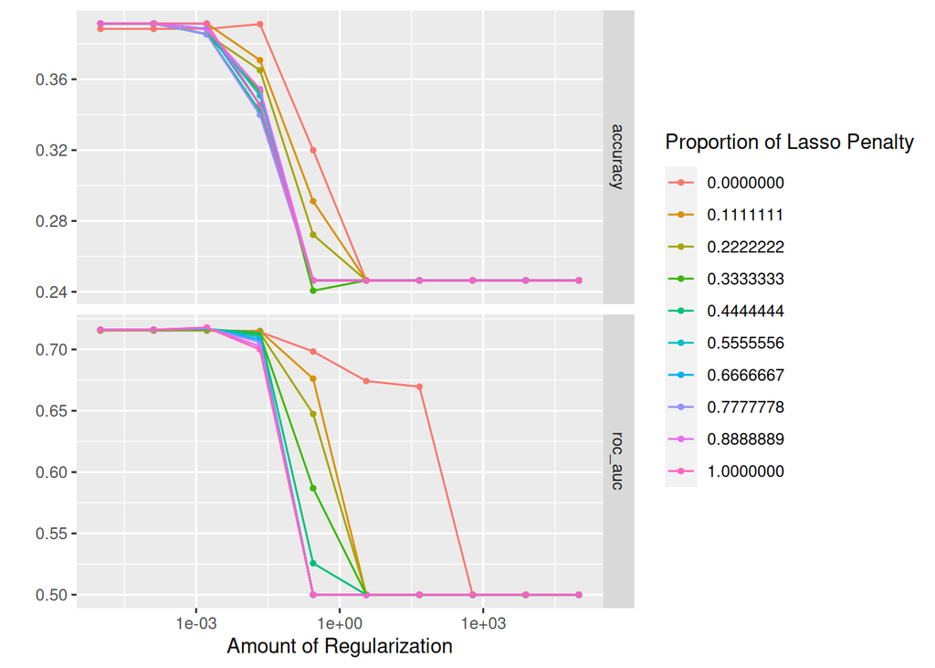

```r
autoplot(elastic_res)
```

```r
collect_metrics(elastic_res)
```

```
## # A tibble: 200 × 8
##     penalty mixture .metric  .estimator  mean     n std_err .config
##       <dbl>   <dbl> <chr>    <chr>      <dbl> <int>   <dbl> <chr>
##  1 0.00001        0 accuracy multiclass 0.388     5  0.0413 Preprocessor1_Model…
##  2 0.00001        0 roc_auc  hand_till  0.715     5  0.0253 Preprocessor1_Model…
##  3 0.000129       0 accuracy multiclass 0.388     5  0.0413 Preprocessor1_Model…
##  4 0.000129       0 roc_auc  hand_till  0.715     5  0.0253 Preprocessor1_Model…
##  5 0.00167        0 accuracy multiclass 0.388     5  0.0413 Preprocessor1_Model…
##  6 0.00167        0 roc_auc  hand_till  0.715     5  0.0253 Preprocessor1_Model…
##  7 0.0215         0 accuracy multiclass 0.391     5  0.0418 Preprocessor1_Model…
##  8 0.0215         0 roc_auc  hand_till  0.714     5  0.0243 Preprocessor1_Model…
##  9 0.278          0 accuracy multiclass 0.320     5  0.0131 Preprocessor1_Model…
## 10 0.278          0 roc_auc  hand_till  0.698     5  0.0180 Preprocessor1_Model…
## # … with 190 more rows
```

# Q7

```r
best_penalty <- select_best(elastic_res, metric = "roc_auc")
best_penalty
```

```
## # A tibble: 1 × 3
##   penalty mixture .config
##     <dbl>   <dbl> <chr>
## 1 0.00167       1 Preprocessor1_Model093
```

```r
elastic_final <- finalize_workflow(elastic_workflow, best_penalty)
elastic_fit <- fit(elastic_final, data = pokemon_training)
elastic_aug <- augment(elastic_fit, new_data = pokemon_testing)
conf_matrix <- elastic_aug %>%
    conf_mat(truth = type_1, estimate = .pred_class)

elastic_aug %>%
    accuracy(truth = type_1, estimate = .pred_class)
```

```
## # A tibble: 1 × 3
##   .metric  .estimator .estimate
##   <chr>    <chr>          <dbl>
## 1 accuracy multiclass     0.359
```

# Q8

```r
elastic_aug %>%
    roc_auc(type_1, .pred_Bug:.pred_Water)
```

```
## # A tibble: 1 × 3
##   .metric .estimator .estimate
##   <chr>   <chr>          <dbl>
## 1 roc_auc hand_till      0.691
```

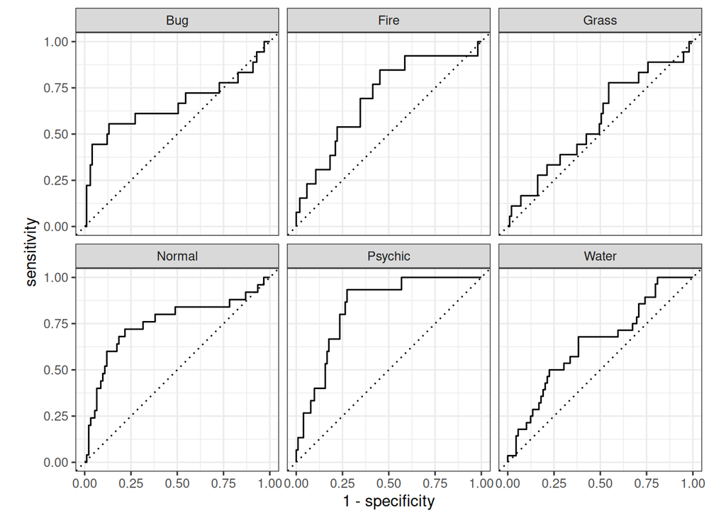

```r
elastic_aug %>%
    roc_curve(type_1, .pred_Bug:.pred_Water) %>%
    autoplot()
```

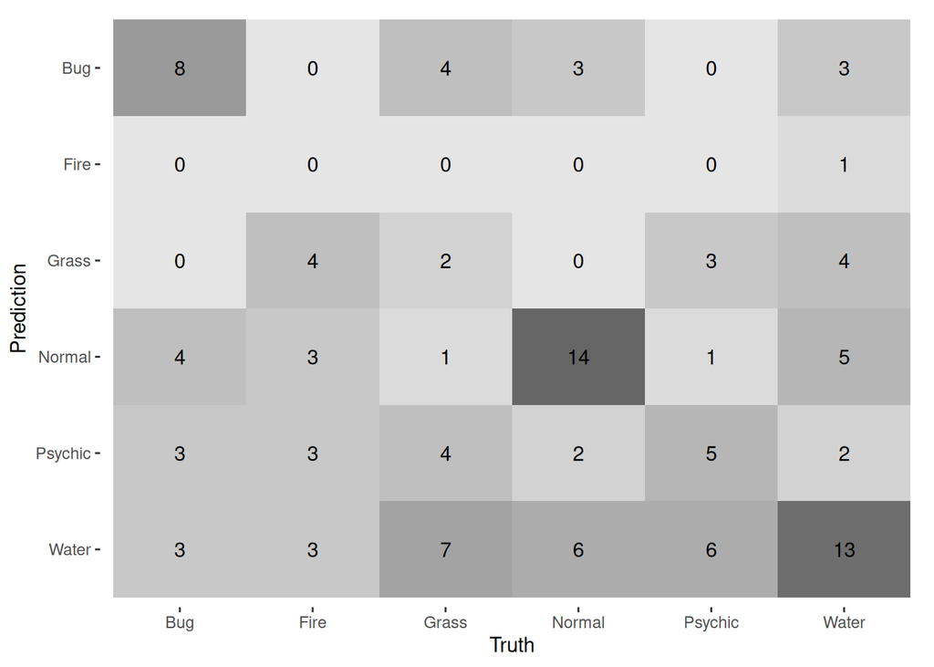

```r
conf_matrix %>%
    autoplot(type="heatmap")
```

model has medium to low accuracy

Normal types have relatively unique stats. They have lowest special attack and higher HP in general, thus larger coefficient on those unique stats Comparatively, Water and fire have similar average stats, thus their coefficient are close

# Q9

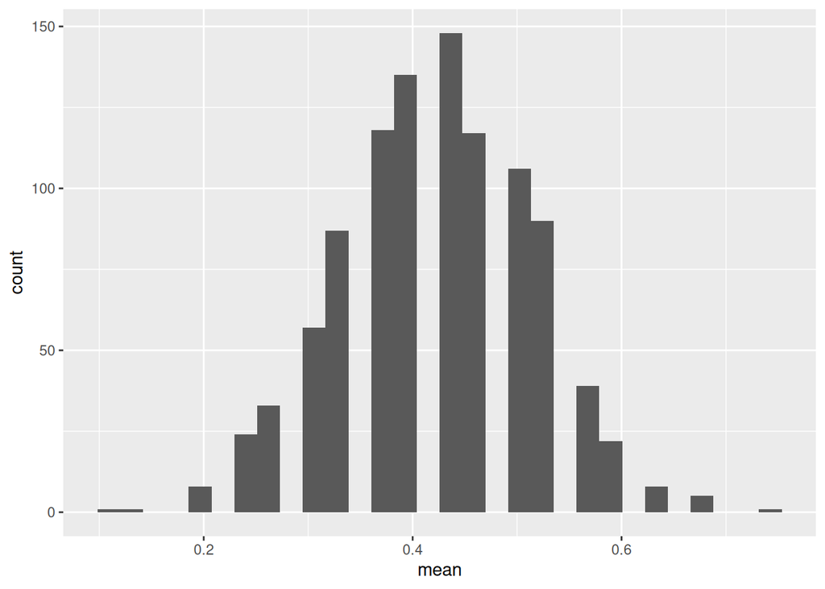

```r
library(boot)
shots <- c(rep(1, 337), rep(0, 464))
means <- c()

for (x in 1:1000) {
    s <- sample(shots, 30)
    means <- append(means, mean(s))
}

data.frame(mean = means) %>%
    ggplot(aes(x = mean)) +
    geom_histogram()
```

```r
quantile(means, probs = c(0.01, 0.99))
```

```
##        1%       99%
## 0.2330000 0.6333333
```